# Air Quality Data Available in openair

David Carslaw

2019-05-05

# Access site information

{{% alert note %}} The UK has a surprisingly large amount of air quality data available. The main national network is called the [Automatic Urban and Rural Network](https://uk-air.defra.gov.uk/networks/network-info?view=aurn). There are however other large networks including the [Scottish Air Quality Network](http://www.scottishairquality.scot/) and the [Welsh Air Quality Network](https://airquality.gov.wales/). One of the largest — if not the largest urban air quality network is the [London Air Quality Network](https://www.londonair.org.uk/LondonAir/Default.aspx) {{% /alert %}}

openair includes the function `importMeta` to provide information on UK air pollution monitoring sites. There are currently four networks that openair has access to:

- The Defra Automatic Urban and Rural Network (AURN)
- The Scottish Air Quality Network (SAQN)
- The Welsh Air Quality Network (WAQN)
- Network(s) operated by King’s College London (KCL)

These functions are described in more detail [here](http://davidcarslaw.github.io/openair/reference/index.html).

The `importMeta` function is the first place to look to discover what sites exist, site type (e.g. traffic, background, rural) and latitude and longitude.

```r
# first load openair
library(openair)

aurn <- importMeta(source = "aurn")

head(aurn)
```

```
## # A tibble: 6 x 5
##   site                           code  latitude longitude site_type
##   <chr>                          <chr>    <dbl>     <dbl> <chr>
## 1 London A3 Roadside             A3        51.4    -0.292 Urban Traffic
## 2 Aberdeen                       ABD       57.2    -2.09  Urban Background
## 3 Aberdeen Union Street Roadside ABD7      57.1    -2.11  Urban Traffic
## 4 Aberdeen Wellington Road       ABD8      57.1    -2.09  Urban Traffic
## 5 Auchencorth Moss               ACTH      55.8    -3.24  Rural Background
## 6 Birmingham Acocks Green        AGRN      52.4    -1.83  Urban Background
```

```r
table(aurn$site.type)
```

```
## < table of extent 0 >
```

Sometimes it is necessary to have more information on the sites such as when they started (or stopped) measuring, the pollutants measured and the regions in which they exist. Additional site information can be obtained using the option `all = TRUE`. In the example below, we will select sites that measure NO<sub>2</sub> at traffic locations.

```r
library(tidyverse)
aurn_detailed <- importMeta(source = "aurn", all = TRUE)

no2_sites <- filter(
  aurn_detailed,
  variable == "NO2",
  site_type == "Urban Traffic"
)

nrow(no2_sites)
```

```
## [1] 85
```

# Plot sites on a map

Since openair started there have been huge developments with R and optional packages. These developments have made it much easier to manipulate and plot data e.g. with ggplot2 and the likes of dplyr. There is also now much more focus on interactive plotting, which is very useful in the context of considering air pollution sites.

In the example below the unique sites are selected from `aurn_detailed` because the `site` repeats the number of pollutants that are measured. Information is also collected for the map popups and then the map is plotted.

```r
library(leaflet)

aurn_unique <- distinct(aurn_detailed, site, .keep_all = TRUE)

# information for map markers
content <- paste(
  paste(
    aurn_unique$site,
    paste("Code:", aurn_unique$code),
    paste("Start:", aurn_unique$date_started),
    paste("End:", aurn_unique$date_ended),
    paste("Site Type:", aurn_unique$site_type),
    sep = "<br/>"
  )
)


# plot map
leaflet(aurn) %>%
  addTiles() %>%
  addMarkers(~ longitude, ~ latitude, popup = content,
             clusterOptions = markerClusterOptions())
```

[interactive chart not shown]

# Access the data

The information above should help to describe the air quality data that is easily available through openair. Access to the data is possible through a family of functions that all tend to work in a similar way. Only two pieces of information are required: the site code(s) and the year(s) of interest.

So, to import data for the industrial Port Talbot Margam site (close to a steelworks) with the site code “PT4” for 2015 to 2018, we can:

```r
margam <- importWAQN(site = "pt4", year = 2015:2018)
```

```
## PT4_2015 does not exist - ignoring that one.
```

This data also includes estimates of wind speed and direction (`ws` and `wd`) from the WRF model, so we can easily plot the distribution of concentrations by wind direction. This plot indicates that the highest PM$_{10}$ concentrations are from the south-west i.e. the steelworks direction. A better indication of important steelworks combustion sources can be seen by plotting SO$_2$.

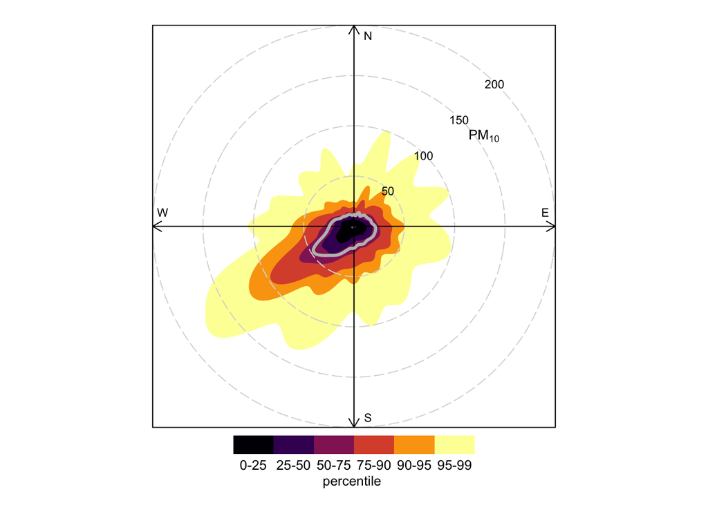

```r
percentileRose(margam,
               pollutant = "pm10",
               percentile = c(25, 50, 75, 90, 95, 99),
               cols = "inferno",
               smooth = TRUE
               )
```